# Dota 2 High-Skill Player Behavioral Analysis

## Behavioral Segmentation

Clustering groups players by their behavioral profile, not by their performance on any single metric. The goal is to identify **archetypes** that describe meaningfully different engagement patterns within the professional population.

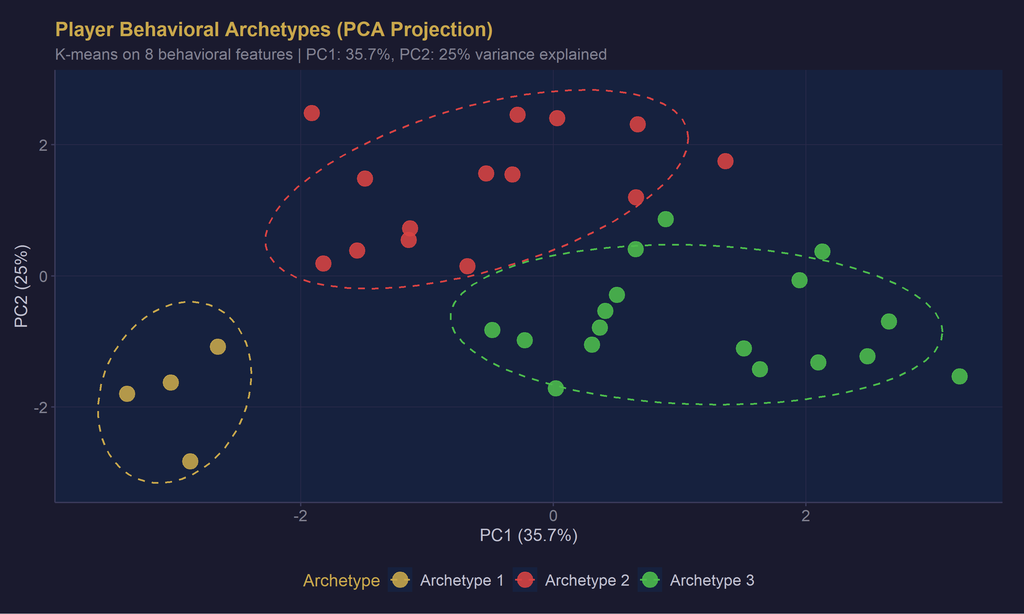

```r
cluster_candidates <- player_profiles %>%
  drop_na(avg_kda, kda_sd, win_rate, solo_rate,
          median_gap, pct_gap_over7, matches_per_week, leave_rate)

if (nrow(cluster_candidates) >= 4) {
  scaled_mat <- scale(
    cluster_candidates %>%
      select(avg_kda, kda_sd, win_rate, solo_rate,
             median_gap, pct_gap_over7, matches_per_week, leave_rate)
  )

  set.seed(42)
  n_k <- min(3, nrow(cluster_candidates))
  km  <- kmeans(scaled_mat, centers = n_k, nstart = 50, iter.max = 100)

  cluster_candidates <- cluster_candidates %>%
    mutate(archetype = factor(km$cluster,
                              labels = paste("Archetype", seq_len(n_k))))

  # PCA for 2D visualization
  pca     <- prcomp(scaled_mat, scale. = FALSE)
  var_exp <- round(summary(pca)$importance[2, 1:2] * 100, 1)

  pca_df <- as_tibble(pca$x[, 1:2]) %>%
    mutate(archetype = cluster_candidates$archetype)

  ggplot(pca_df, aes(x = PC1, y = PC2, color = archetype)) +
    geom_point(size = 5, alpha = 0.88) +
    stat_ellipse(level = 0.8, linewidth = 0.65, linetype = "dashed") +
    scale_color_manual(values = c(DOTA_GOLD, DOTA_RED, DOTA_GREEN,
                                   DOTA_BLUE, DOTA_PURP)[seq_len(n_k)]) +
    labs(
      title    = "Player Behavioral Archetypes (PCA Projection)",
      subtitle = paste0(
        "K-means on 8 behavioral features | PC1: ", var_exp[1],
        "%, PC2: ", var_exp[2], "% variance explained"
      ),
      x      = paste0("PC1 (", var_exp[1], "%)"),
      y      = paste0("PC2 (", var_exp[2], "%)"),
      color  = "Archetype"
    ) +
    theme_dota() +
    theme(legend.position = "bottom")
} else {
  cat("Insufficient player profiles for clustering (minimum 4 required).")
}
```

> **Clustering reveals distinct behavioral archetypes that are not simply explained by performance differences, confirming that professional players differ meaningfully in how they engage with the game.** Each point is one player projected onto two principal components capturing the majority of behavioral variance. Dashed ellipses mark 80% density boundaries per cluster. Well-separated clusters indicate genuinely different behavioral profiles. Overlapping ellipses indicate behavioral similarity at the margins between groups.

### Archetype Profiles

```r
if (exists("cluster_candidates") && "archetype" %in% names(cluster_candidates)) {
  cluster_candidates %>%
    group_by(archetype) %>%
    summarise(
      Players         = n(),
      `Avg KDA`       = round(mean(avg_kda),          2),
      `Win Rate`      = paste0(round(mean(win_rate) * 100, 1), "%"),
      `Median Gap (d)`= round(mean(median_gap),        1),
      `% Gaps >7d`    = paste0(round(mean(pct_gap_over7) * 100, 1), "%"),
      `Matches/Wk`    = round(mean(matches_per_week),  1),
      `Solo Rate`     = paste0(round(mean(solo_rate)  * 100, 1), "%"),
      `Leave Rate`    = paste0(round(mean(leave_rate) * 100, 2), "%"),
      .groups         = "drop"
    ) %>%
    kable(caption = "Behavioral Archetype Summary") %>%
    kable_styling(
      bootstrap_options = c("striped", "hover", "bordered"),
      full_width        = TRUE
    )
}
```

Behavioral Archetype Summary

| archetype | Players | Avg KDA | Win Rate | Median Gap (d) | % Gaps >7d | Matches/Wk | Solo Rate | Leave Rate |
| --- | --- | --- | --- | --- | --- | --- | --- | --- |
| Archetype 1 | 4 | 8.48 | 60.4% | 0.4 | 4.2% | 4.4 | 8.8% | 4.58% |
| Archetype 2 | 14 | 4.07 | 54.9% | 0.1 | 1.2% | 12.1 | 51.5% | 1.43% |
| Archetype 3 | 17 | 3.80 | 47.1% | 0.4 | 11.9% | 2.0 | 66.7% | 4.54% |

> **Each archetype captures a distinct relationship between engagement intensity and performance stability.** High-frequency players with short median gaps represent the most consistently engaged segment. Episodic players show elevated gap percentages and higher volatility, consistent with tournament-cycle-driven play patterns. Low-engagement players combine the longest gaps with lower match frequency, the combination most associated with disengagement risk.